# Theory of Computation

Reagan Shirk

September 10, 2019

# Example (NFA to DFA)

- NFA we’re looking at

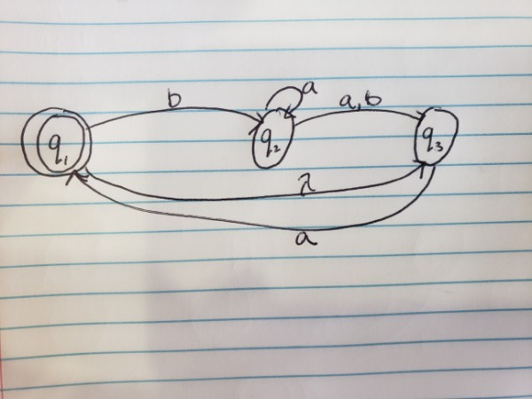

NFA Diagram

- Equivalent DFA $M$
  - Accepting states are any states that include 1
  - DFA can only have one starting state, you have to start at {1, 3} because of the lambda transition
  - Formally we need to look at states {1, 2} and {1} because we need the definition but we can see that we’ll never actually need those states (because there are no arrows going into those states)
  - Can someone tell me why {1} goes to {2} with a b and not to {2, 3}?

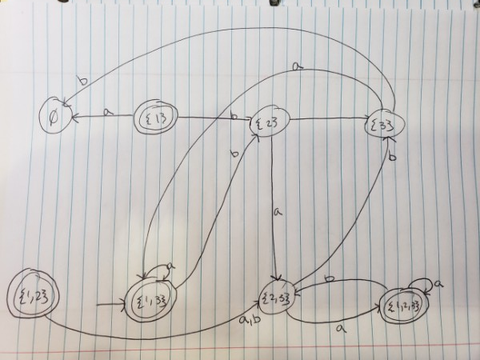

DFA Diagram

- $\Sigma = \left\{a, b\right\}$
- $q_{oM} = \Lambda(\left\{q_{oN}\right\})$

# Closure under Regular Operations

## Union

- Concatenation was an issue before we introduced NFAs
- Theorem: The class of regular languages is closed under $\cup$.
- Proof idea: “Guess” the language where the input $w$ belongs to and see if we accept
  - Multiple NFAs with one starting state, several intermediate states, and several accepting states
  - pick a starting state outside of either NFA ($q_o$) and go to either NFA in lambda, see which one accepts?
    - Could have one accepting state outside of the NFAs that accepts all of the accepting states from the NFAs if desired
- Proof
  - Let $N_1 = (Q_1, \Sigma, \delta_1, q_1, F_1)$
  - Let $N_2 = (Q_2, \Sigma, \delta_2, q_2, F_2)$
  - Construct $N = (Q, \Sigma, \delta, q_o, F)$ such that
    - $Q = Q_1 \cup Q_2 \cup \left\{q_o\right\}$
    - $q_o$ is the starting state for $N$
    - $F = F_1 \cup F_2$
    - $\delta(q, a)$ is:
      - $\delta_1(q, a), q \in Q_1$
      - $\delta_2(q, a), q \in Q_2$
      - $\left\{q_1, q_2\right\}, q = q_o, a = \lambda$
      - $\left\{\right\}, q = q_o, a \neq \lambda$

## Concatenation

- Theorem: The class of regular languages is closed under $\circ$
- Proof Idea: There is an NFA $N_1$ with starting state $q_1$ that would normally have a bunch of accepting states and some intermediate states. There is an NFA $N_2$ with starting state $q_1$ and a bunch of accepting states and some intermediate states. Ignore the accepting states of $N_1$ and introduce $\lambda$ rows to the starting state of $N_2$
- Proof
  - Let $N_1 = \left(Q_1, \Sigma, \delta_1, q_1, F_1\right)$
  - Let $N_2 = \left(Q_2, \Sigma, \delta_2, q_2, F_2\right)$
  - Construct $N = \left(Q, \Sigma, \delta, q_o, F\right)$
    - $Q = Q_1 \cup Q_2$
    - $q_o = q_1$
    - $F = F_2$
    - $\Sigma = \Sigma$
    - $\delta(q, a)$ is:
      - $\delta_1(q, a), q \in Q_1, F_1$
      - $\delta_2(q, a), q \in Q_2$
      - $\delta_1(q, a) \cup Q_2, q \in F_1$

## Star

- Theorem: The class of regular languages is closed under the star operation
  - $L_1^* = \left\{w_1,w_1,...,w_n | w_i \in L_1\right\} = \cup_{k=0}^{\infty}L^k$
  - $L_1^* = \left\{w^* | w_i \in L_1\right\}$
- Proof idea: There is an NFA $N_1$ of $L_1$ with one starting state, many accepting states, and some intermediate states. There are lambda transitions from each accepting state back to the starting state. We need to introduce an artificial accepting/starting state that goes to $q_1$ with $\lambda$
- Proof:
  - Let $N_1 = \left(Q_1, \Sigma, \delta_1, q_1, F_1\right)$
  - Construct $N = \left(Q, \Sigma, \delta, q_o, F\right)$ such that:
    - $Q = Q \cup \left\{q_o\right\}$
    - $\Sigma$ is common $\left(\Sigma = \Sigma\right)$
    - $q_o$ is the new starting state
    - $F = F_1 \cup \left\{q_o\right\}$
    - $\delta(q, a)$ is:
      - $\delta(q, a), q \in Q_1, F_1$
      - $\delta(q, a) \cup q_1, q \in F_1$
      - $\left\{q_1\right\}, q = q_o, a = \lambda$
      - $\left\{\right\}, q = q_o, a \neq \lambda$

# Regular Expressions

- Example: $\left(0 \cup 1\right)0^*$
  - The value of a regular expression is a language
  - $0 \cup 1$ really means $\left\{0\right\} \cup \left\{1\right\}$ which is $\left\{0, 1\right\}$
  - $0^*$ means $\left\{0^*\right\}$
    - $\lambda$ can be part of this language
  - $\left(0 \cup 1\right)0^*$ that we have is really shorthand for $\left(0 \cup 1\right) \circ 0^*$
- Examples:
  - $\left(0 \cup 1\right)^* = \left\{\left\{\right\}, 0, 1, 00, 01, 10, 11, 000, ...\right\}$
  - $\Sigma = \left\{0, 1\right\}$ then $\left\{0, 1\right\}^*$ is equal to what is above
  - $\Sigma$ is shorthand for $\left(0 \cup 1\right)$
  - $\Sigma^*1$ = binary strings ending in $1$